# Partially observed functional data

Hyunsung Kim

2021-02-24

# Lin & Wang (2020) + Huber Loss

## Local polynomial kernel smoothing

- The estimation of $\mu(t)$ and $\sigma_X^2(t)$ be $\hat{b}_0$ from the following minimization criterions:
  $$\begin{align}
  (\hat{b}_0, \hat{b}_1) &= \underset{(b_0,b_1) \in \mathbb{R}^2}{\operatorname{\arg\min}} \sum_{i=1}^n w_i \sum_{j=1}^{m_i} K_{h_{\mu}} (T_{ij}-t) \{ Y_{ij} - b_0 - b_1(T_{ij}-t) \}^2, \\
  (\hat{b}_0, \hat{b}_1) &= \underset{(b_0,b_1) \in \mathbb{R}^2}{\operatorname{\arg\min}} \sum_{i=1}^n w_i \sum_{j=1}^{m_i} K_{h_{\sigma}} (T_{ij}-t) \left[ \{Y_{ij} - \hat{\mu}(T_{ij})\}^2 - b_0 - b_1(T_{ij}-t) \right]^2,
  \end{align}$$
  where $K$ be a kernel function, $h_{\mu}, h_{\sigma}$ bandwidths for $\mu$ and $\sigma_X^2$, $w$ weight.
- 위 식은 weighted least squares (WLS)로 solution을 찾을 수 있음.

## Local polynomial kernel smoothing with Huber loss

- Non-parametric method for estimating $\mu(t)$ and $\sigma_X^2(t)$
- The estimation of $\mu(t)$ and $\sigma_X^2(t)$ be $\hat{b}_0$ from the following minimization criterions:
  $$\begin{align}
  (\hat{b}_0, \hat{b}_1) &= \underset{(b_0,b_1) \in \mathbb{R}^2}{\operatorname{\arg\min}} \sum_{i=1}^n \rho \left[ w_i \sum_{j=1}^{m_i} K_{h_{\mu}} (T_{ij}-t) \{ Y_{ij} - b_0 - b_1(T_{ij}-t) \} \right], \\
  (\hat{b}_0, \hat{b}_1) &= \underset{(b_0,b_1) \in \mathbb{R}^2}{\operatorname{\arg\min}} \sum_{i=1}^n \rho \left[ w_i \sum_{j=1}^{m_i} K_{h_{\sigma}} (T_{ij}-t) \left[ \{Y_{ij} - \hat{\mu}(T_{ij})\}^2 - b_0 - b_1(T_{ij}-t) \right] \right],
  \end{align}$$
  where
  $$\rho(x) =
  \begin{cases}
  \frac{1}{2}x^2, & |a| \le k \\
  k(|x| - \frac{1}{2}k), & |a| > k.
  \end{cases}$$
- 위 식은 iterated re-weighted least squares (IWLS)으로 solution을 찾을 수 있음. (`rlm()` in `MASS`)
- IWLS 적용 전, response와 predictors를 weighted variable로 변환해주어야함. (WLS scheme)
- Huber function에서 $k = 1.345$로 고정.

## Cross validation for optimal bandwidth $h$

- The bandwidths for kernel smoothing, $h_{\mu}, h_{\sigma}$, be selected by $\mathcal{K}$-fold cross validation, which minimizes the following CV errors:
  $$\begin{align}
  \text{CV}(h_{\mu}) &= \sum_{k=1}^{\mathcal{K}} \sum_{i \in \mathcal{P}_k} \sum_{j=1}^{m_i} \left\{ Y_{ij} - \hat{\mu}_{h_{\mu},-k}(T_{ij}) \right\}^2 \\
  \text{CV}(h_{\sigma}) &= \sum_{k=1}^{\mathcal{K}} \sum_{i \in \mathcal{P}_k} \sum_{j=1}^{m_i} \left[ \{ Y_{ij} - \hat{\mu}(T_{ij}) \}^2 - \hat{\sigma}_X^2(T_{ij}) \right]^2
  \end{align}$$

## Problems

- Huber loss로 대체하여 추정된 variance estimator($\hat{\sigma}_X^2$)는 error variance($\hat{\sigma}_0^2$)를 빼지 않은 값임. (원래 이 값을 빼주어야 정확한 estimator임.)
- Outlier가 포함된 데이터로부터 Lin & Wang (2020) 방법으로 추정된 $\hat{\sigma}_0^2$는 매우 큰 값을 가짐. (이 값을 빼게 되면 variance estimator가 모두 음수가 되어 실직적인 값은 0으로 추정된 것임.)
- 따라서 $\sigma_0^2$ 또한 robust하게 estimate하는 방법을 생각해봐야할 것으로 보임

# Results for covariance estimation

- CV를 통해 optimal한 bandwidth를 찾아야하지만, 이번 결과에서는 cv error 계산식에서 오류가 발견되어 임의로 선택한 것이라 생각하면 될 것 같습니다.
- Variance estimation에서 `huber()` in `MASS`를 사용한 방법은 local kernel smoothing이 아닌 각 time point에서의 값으로 구한 location estimation이다보니 결과 요약에서 제외함. (Figure 1과 대응되는 그림은 Appendix 참고)

## Variance estimation

- Yao (2005)의 경우, variance estimator가 음수가 나오기도 함. (함수 내에서 따로 처리해주지 않음)
- Lin (2020)의 경우, `mcfda`의 함수에서 estimator가 음수가 나오면 0으로 처리함.

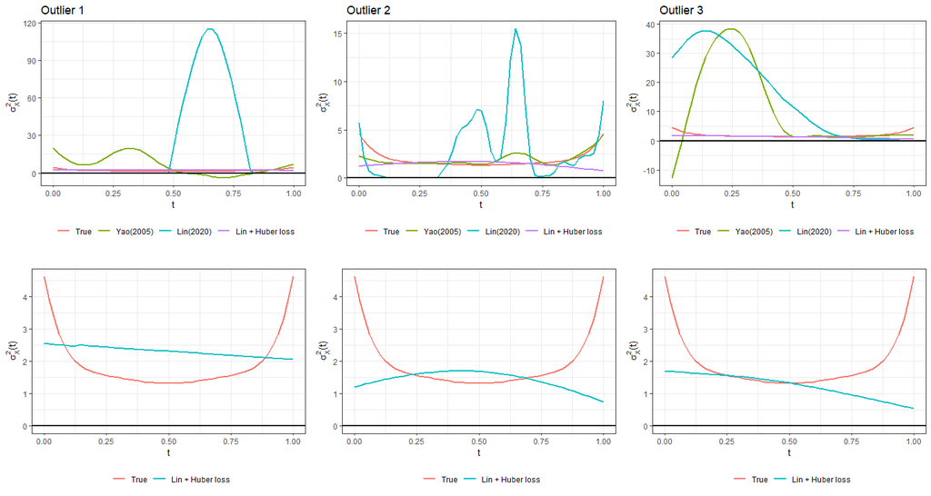

Figure 1. Trajectories of true and estimated variances.

## Covariance estimation

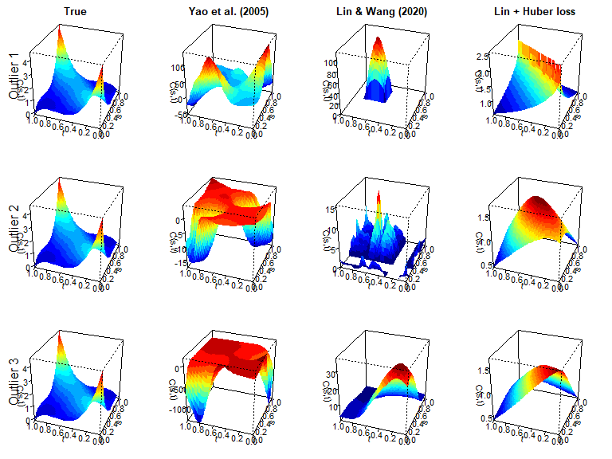

Figure 2. True covariance surface and estimated covariance surfaces.

Table 1. Average RMISE (standard error) of variances($\hat{\sigma}_X^2$) and covariances($\hat{\mathbf{C}}$) estimation.

|  | $N$ | $\hat{\sigma}_X^2$ Yao (2005) | $\hat{\sigma}_X^2$ Lin (2020) | $\hat{\sigma}_X^2$ Lin + Huber loss | $\hat{\mathbf{C}}$ Yao (2005) | $\hat{\mathbf{C}}$ Lin (2020) | $\hat{\mathbf{C}}$ Lin + Huber loss |
| --- | --- | --- | --- | --- | --- | --- | --- |
| Outlier 1 | 69 | 13.47(658.4) | 45.42(5381.75) | 1.12(1.76) | 136.58(121957.72) | 20.45(1117.23) | 0.64(0.24) |
| Outlier 2 | 64 | 10.8(558.58) | 28.04(2703.48) | 1.05(0.54) | 105.2(68976.71) | 13.92(630.53) | 0.56(0.19) |
| Outlier 3 | 73 | 1652.42(19867496.28) | 1618.94(15140557.18) | 1.14(0.82) | 8537.29(589267529.24) | 761.98(3208396.06) | 0.58(0.21) |

Table 2. Average MISE (standard error) of covariance estimation between intrapolation($\mathcal{D}_0$) and extrapolation($\mathcal{S}_0 \backslash \mathcal{D}_0$) parts.

|  | $N$ | $\mathcal{D}_0$ Yao (2005) | $\mathcal{D}_0$ Lin (2020) | $\mathcal{D}_0$ Lin + Huber loss | $\mathcal{S}_0 \backslash \mathcal{D}_0$ Yao (2005) | $\mathcal{S}_0 \backslash \mathcal{D}_0$ Lin (2020) | $\mathcal{S}_0 \backslash \mathcal{D}_0$ Lin + Huber loss |
| --- | --- | --- | --- | --- | --- | --- | --- |
| Outlier 1 | 69 | 78.73(253.5) | 388.98(1038.05) | 0.21(0.16) | 18576.26(121950.35) | 29.07(112.75) | 0.19(0.15) |
| Outlier 2 | 64 | 74.7(320.84) | 184.04(598.48) | 0.23(0.16) | 10992.35(68686.95) | 9.64(38.08) | 0.07(0.07) |
| Outlier 3 | 73 | 1499511.73(8187863.5) | 563682(3134268.85) | 0.25(0.17) | 71385831.63(582714821.02) | 16928.68(92889.5) | 0.09(0.07) |

# Results for PCA

## Estimated first 3 eigenfunctions

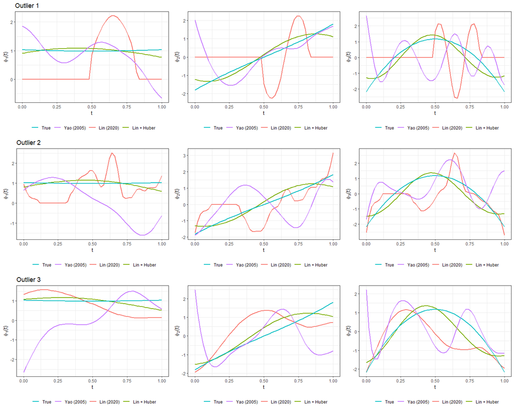

Figure 3. Estimated first 3 eigenfunctions for 1st simulation data.

## MISE for first 3 eigenfunctions

Table 2. Average MISE (standard error) of first 3 eigenfunctions.

|  | $N$ | Yao (2005) | Lin (2020) | Lin + Huber loss |
| --- | --- | --- | --- | --- |
| Outlier 1 | 69 | 1.94(0.91) | 1.99(0.79) | 0.6(0.31) |
| Outlier 2 | 64 | 1.92(1.05) | 1.78(1.49) | 0.61(0.3) |
| Outlier 3 | 73 | 1.96(1.03) | 1.23(1.41) | 0.66(0.39) |

# Appendix

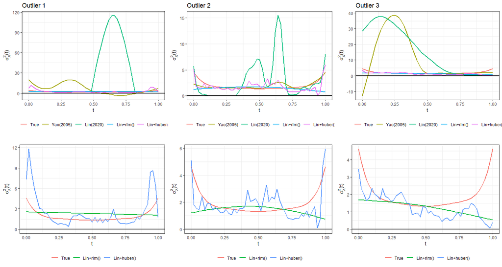

Figure 4. Trajectories of true and estimated variances.